# CSDA1010SUMA18 - LAB EXERCISE 3: Classification Problem

```r
library(readr)
library(dplyr)
library(ggplot2)
library(rpart)
library(rpart.plot)
library(Amelia)
library(rattle)
library(RColorBrewer)
library(caret)
```

# Nursery Data Set reference and short description

Source: http://archive.ics.uci.edu/ml/datasets/Nursery

```
| class values

not_recom, recommend, very_recom, priority, spec_prior

| attributes

parents:     usual, pretentious, great_pret.
has_nurs:    proper, less_proper, improper, critical, very_crit.
form:        complete, completed, incomplete, foster.
children:    1, 2, 3, more.
housing:     convenient, less_conv, critical.
finance:     convenient, inconv.
social:      nonprob, slightly_prob, problematic.
health:      recommended, priority, not_recom.
```

```r
nursery_data <- read.csv("http://archive.ics.uci.edu/ml/machine-learning-databases/nursery/nursery.data", header = FALSE, col.names = c("parents","has_nurs","form","children","housing","finance","social","health","class"))
# nursery_data <- read.csv(file = "../data/nursery_data.csv")
```

# Data Set exploration and cleaning

```r
set.seed(77)
dim(nursery_data)
```

```
[1] 12960     9
```

```r
#head(nursery_data)
#str(nursery_data)
```

## Coding for categorical variables

## Reorder factors

Very often, especially when plotting data, we need to reorder the levels of a factor because the default order is alphabetical. A direct way of reordering, using standard syntax is as follows.

Current levels, need to be corrected to correspont to the dataset description

```r
print (levels(nursery_data$parents))
```

```
[1] "great_pret"  "pretentious" "usual"
```

```r
print (levels(nursery_data$has_nurs))
```

```
[1] "critical"    "improper"    "less_proper" "proper"      "very_crit"
```

```r
print (levels(nursery_data$form))
```

```
[1] "complete"   "completed"  "foster"     "incomplete"
```

```r
print (levels(nursery_data$children))
```

```
[1] "1"    "2"    "3"    "more"
```

```r
print (levels(nursery_data$housing))
```

```
[1] "convenient" "critical"   "less_conv"
```

```r
print (levels(nursery_data$finance))
```

```
[1] "convenient" "inconv"
```

```r
print (levels(nursery_data$social))
```

```
[1] "nonprob"       "problematic"   "slightly_prob"
```

```r
print (levels(nursery_data$health))
```

```
[1] "not_recom"   "priority"    "recommended"
```

```r
print (levels(nursery_data$class))
```

```
[1] "not_recom"  "priority"   "recommend"  "spec_prior" "very_recom"
```

Correction:

```r
nursery_data$parents <- factor(nursery_data$parents,levels(nursery_data$parents)[c(3,2,1)])
nursery_data$has_nurs <- factor(nursery_data$has_nurs,levels(nursery_data$has_nurs)[c(4,3,2,1,5)])
nursery_data$form <- factor(nursery_data$form,levels(nursery_data$form)[c(1,2,4,3)])
nursery_data$children <- factor(nursery_data$children,levels(nursery_data$children)[c(1,2,3,4)])
nursery_data$housing <- factor(nursery_data$housing,levels(nursery_data$housing)[c(1,3,2)])
nursery_data$finance <- factor(nursery_data$finance,levels(nursery_data$finance)[c(1,2)])
nursery_data$social <- factor(nursery_data$social,levels(nursery_data$social)[c(1,3,2)])
nursery_data$health <- factor(nursery_data$health,levels(nursery_data$health)[c(1,3,2)])
nursery_data$class <- factor(nursery_data$class,levels(nursery_data$class)[c(1,3,5,2,4)])
```

Corrected levels, now correspond to the dataset description

```r
print (levels(nursery_data$parents))
```

```
[1] "usual"       "pretentious" "great_pret"
```

```r
print (levels(nursery_data$has_nurs))
```

```
[1] "proper"      "less_proper" "improper"    "critical"    "very_crit"
```

```r
print (levels(nursery_data$form))
```

```
[1] "complete"   "completed"  "incomplete" "foster"
```

```r
print (levels(nursery_data$children))
```

```
[1] "1"    "2"    "3"    "more"
```

```r
print (levels(nursery_data$housing))
```

```
[1] "convenient" "less_conv"  "critical"
```

```r
print (levels(nursery_data$finance))
```

```
[1] "convenient" "inconv"
```

```r
print (levels(nursery_data$social))
```

```
[1] "nonprob"       "slightly_prob" "problematic"
```

```r
print (levels(nursery_data$health))
```

```
[1] "not_recom"   "recommended" "priority"
```

```r
print (levels(nursery_data$class))
```

```
[1] "not_recom"  "recommend"  "very_recom" "priority"   "spec_prior"
```

## Convert to numbers in one step

[Ref] (https://stackoverflow.com/questions/47922184/convert-categorical-variables-to-numeric-in-r)

```r
data <- data.matrix(nursery_data)
head(data)
```

```
     parents has_nurs form children housing finance social health class
[1,]       1        1    1        1       1       1      1      2     2
[2,]       1        1    1        1       1       1      1      3     4
[3,]       1        1    1        1       1       1      1      1     1
[4,]       1        1    1        1       1       1      2      2     2
[5,]       1        1    1        1       1       1      2      3     4
[6,]       1        1    1        1       1       1      2      1     1
```

## Preparing scaled data and split into train and test

```r
index <- sample(1:nrow(data),round(0.75*nrow(data)))
#index <- createDataPartition(y= data$QLT, p=0.5, list = FALSE)
maxs <- apply(data, 2, max)
mins <- apply(data, 2, min)
scaled <- as.data.frame(scale(data, center = mins, scale = maxs - mins))
train_ <- scaled[index,]
test_ <- scaled[-index,]
```

# The problem

## Distribution of target value in the dataset

```r
prop.table(table(nursery_data$class))
```

```
  not_recom   recommend  very_recom    priority  spec_prior
0.333333333 0.000154321 0.025308642 0.329166667 0.312037037
```

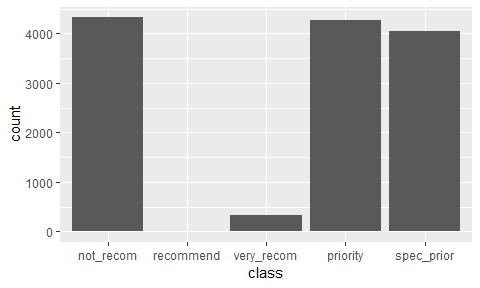

```r
ggplot(data = nursery_data, mapping = aes(x = class)) + geom_bar()
```

# Clustering

A fundamental question is how to determine the value of the parameter k. If we looks at the percentage of variance explained as a function of the number of clusters: One should choose a number of clusters so that adding another cluster doesn’t give much better modeling of the data. More precisely, if one plots the percentage of variance explained by the clusters against the number of clusters, the first clusters will add much information (explain a lot of variance), but at some point the marginal gain will drop, giving an angle in the graph. The number of clusters is chosen at this point, hence the ‘elbow criterion’.

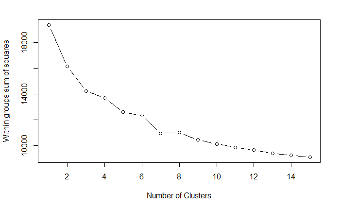

```r
wssplot <- function(data, nc=15, seed=1234){
  wss <- (nrow(data)-1)*sum(apply(data,2,var))
  for (i in 2:nc){
    set.seed(seed)
    wss[i] <- sum(kmeans(data, centers=i)$withinss)}
  plot(1:nc, wss, type="b", xlab="Number of Clusters",
       ylab="Within groups sum of squares")}
wssplot(scaled, nc=15)
```

## Clustering using K-means method

```r
set.seed(420)
clusters_num =5
k.means.fit <- kmeans(scaled, clusters_num,iter.max = 1000)
# attributes(k.means.fit)
k.means.fit$centers
```

```
    parents  has_nurs      form  children   housing finance    social       health        class
1 0.5000000 0.5000000 0.5000000 0.5000000 0.5000000       1 0.5000000 0.0000000000 0.0000000000
2 1.0000000 0.5000000 0.5000000 0.5000000 0.5000000       1 0.5000000 0.7500000000 0.9399305556
3 0.2500000 0.5000000 0.5000000 0.5000000 0.5000000       1 0.5000000 0.7500000000 0.8354166667
4 0.5002316 0.5002316 0.5002316 0.5002316 0.5002316       0 0.5001158 0.7501157943 0.8448355720
5 0.4995375 0.4995375 0.4995375 0.4995375 0.4995375       0 0.4997687 0.0004625347 0.0002312673
```

```r
# plot(k.means.fit$centers[,c("RS","ALC")])
# k.means.fit$cluster
k.means.fit$size
```

```
[1] 2160 1440 2880 4318 2162
```

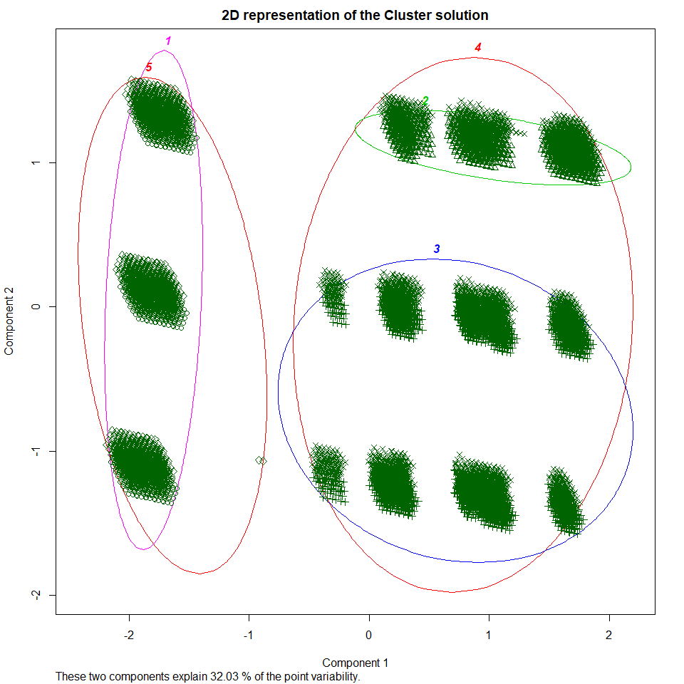

```r
library(cluster)
clusplot(scaled, k.means.fit$cluster, main='2D representation of the Cluster solution',
         color=TRUE, shade=FALSE,
         labels=clusters_num, lines=0)
```

# Explain clusters

## Explain by ‘class’

Let’s try to explain clusters by the ‘class’. Code below builds a matrix whe columns are cluster numbers and rows are target classes.

```r
table(nursery_data$class,k.means.fit$cluster)
```

```
                1    2    3    4    5
  not_recom  2160    0    0    0 2160
  recommend     0    0    0    0    2
  very_recom    0    0  110  218    0
  priority      0  346 1676 2244    0
  spec_prior    0 1094 1094 1856    0
```

# Hierarchical Clustering

```r
d <- dist(scaled, method = "manhattan")
H.fit <- hclust(d, method="ward.D2")
```

The clustering output can be displayed in a dendrogram

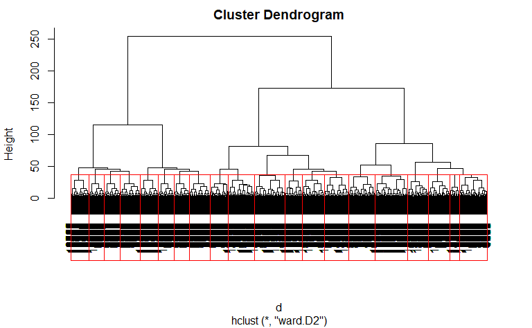

```r
clusters_num = 20
plot(H.fit)
groups <- cutree(H.fit, k=clusters_num)
rect.hclust(H.fit, k=clusters_num, border="red")
```

The clustering performance can be evaluated with the aid of a confusion matrix as follows. Let’s look at the groups that have mixed valued of ‘class’. Group 1 contains class ‘recommend’ and also ‘very_recom’ and ‘priority’. Since our idea is relable rows to ‘recommend’ to increase it’s presense, let’s check if there is any justification to do this.

```r
table(nursery_data$class,groups)
```

```
            groups
                1    2    3    4    5    6    7    8    9   10   11   12   13   14   15   16   17   18   19   20
  not_recom     0  640    0  480    0  640    0  480    0  480    0  480    0    0    0    0    0  560    0  560
  recommend     2    0    0    0    0    0    0    0    0    0    0    0    0    0    0    0    0    0    0    0
  very_recom  208    0    0    0  100    0    0    0   10    0   10    0    0    0    0    0    0    0    0    0
  priority    650    0  636    0  416    0  400    0  650    0  562    0  404    0    8  300    0    0  240    0
  spec_prior   10    0   10    0  176    0  560    0    0    0    8    0  368  820  800    0 1012    0  280    0
```

```r
dif <- colMeans(scaled[groups == 1,]) - colMeans(scaled[groups == 5,])
dif <- dif[order(abs(dif), decreasing = T)]
print(dif)
```

```
    finance        form     housing       class     parents    children      health    has_nurs      social
-1.00000000  0.22487985 -0.12126437 -0.08550262  0.06343100 -0.05783004 -0.03638629 -0.02445020  0.01551724
```

```r
dif <- colMeans(scaled[groups == 5,]) - colMeans(scaled[groups == 9,])
dif <- dif[order(abs(dif), decreasing = T)]
print(dif)
```

```
    finance     housing        form    has_nurs    children      health       class     parents      social
 1.00000000 -0.56515152 -0.30687219  0.22782011 -0.09110761  0.03878963  0.03124453  0.01452093  0.00000000
```

Lets fix the group 1 by relabelling class to ‘recommend’

```r
nursery_data[groups == 1,]$class<- 'recommend'
```

Lets analyze the result Visualize the distribution of class now. Obviosly the distribution is improved compaired to previous data.

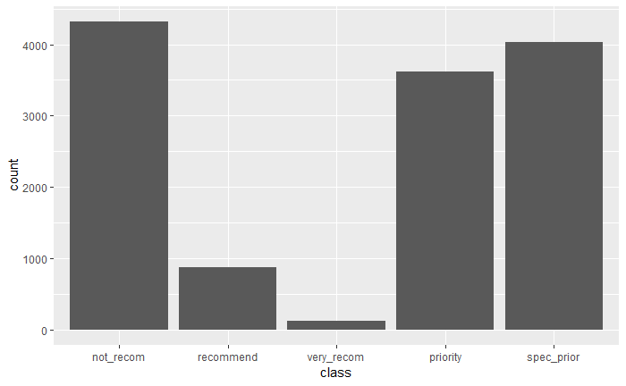

```r
ggplot(data = nursery_data, mapping = aes(x = class)) + geom_bar()
```

Lets create training data

```r
train.rows<- createDataPartition(y= nursery_data$class, p=0.8, list = FALSE)
train.data<- nursery_data[train.rows,]
prop.table((table(train.data$class)))
```

```
  not_recom   recommend  very_recom    priority  spec_prior
0.333301186 0.067123156 0.009258366 0.279004726 0.311312566
```

Visualize the distribution of class on the training data

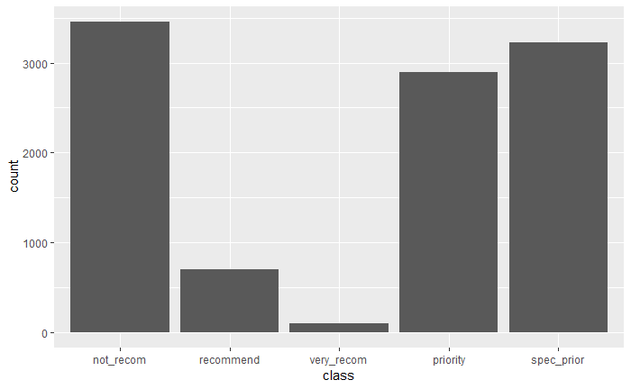

```r
ggplot(data = train.data, mapping = aes(x = class)) + geom_bar()
```

# Iterative data model fit and evaluation

## Interation 1: Decision Tree model fit

```r
fitdt <- rpart(as.factor(class)~., method="class", data=train.data)
```

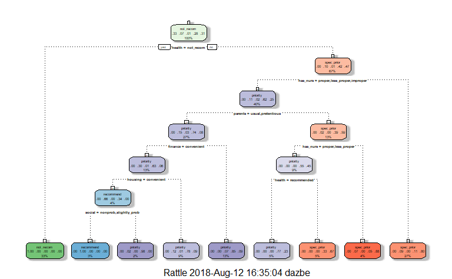

```r
fancyRpartPlot(fitdt)
```

Create test data

```r
test.data<- nursery_data[-train.rows,]
```

Lets see the result

```r
dtPrediction <- predict(fitdt, test.data, type = "class")
head(dtPrediction,n=15)
```

```
        2         9        11        13        28        37        44        55        66        71        74        81        82        84
recommend not_recom  priority  priority  priority  priority  priority recommend not_recom  priority  priority not_recom  priority not_recom
       86
 priority
Levels: not_recom recommend very_recom priority spec_prior
```

```r
head(test.data,n=15)
```

|  | parents | has_nurs | form | children | housing | finance | social | health | class |
| --- | --- | --- | --- | --- | --- | --- | --- | --- | --- |
| 2 | usual | proper | complete | 1 | convenient | convenient | nonprob | priority | recommend |
| 9 | usual | proper | complete | 1 | convenient | convenient | problematic | not_recom | not_recom |
| 11 | usual | proper | complete | 1 | convenient | inconv | nonprob | priority | priority |
| 13 | usual | proper | complete | 1 | convenient | inconv | slightly_prob | recommended | very_recom |
| 28 | usual | proper | complete | 1 | less_conv | inconv | nonprob | recommended | very_recom |
| 37 | usual | proper | complete | 1 | critical | convenient | nonprob | recommended | very_recom |
| 44 | usual | proper | complete | 1 | critical | convenient | problematic | priority | priority |
| 55 | usual | proper | complete | 2 | convenient | convenient | nonprob | recommended | recommend |
| 66 | usual | proper | complete | 2 | convenient | inconv | nonprob | not_recom | not_recom |
| 71 | usual | proper | complete | 2 | convenient | inconv | problematic | priority | priority |

[output cut: 5 more lines]

Evaluate Decision Tree model

```r
confusionMatrix(data=dtPrediction,test.data$class)
```

```
Confusion Matrix and Statistics

            Reference
Prediction   not_recom recommend very_recom priority spec_prior
  not_recom        864         0          0        0          0
  recommend          0        82          0        0          0
  very_recom         0         0          0        0          0
  priority           0        25         24      608         61
  spec_prior         0        67          0      115        745

Overall Statistics

               Accuracy : 0.8873
                 95% CI : (0.8745, 0.8992)
    No Information Rate : 0.3335
    P-Value [Acc > NIR] : < 2.2e-16

                  Kappa : 0.8386
 Mcnemar's Test P-Value : NA

Statistics by Class:

                     Class: not_recom Class: recommend Class: very_recom Class: priority Class: spec_prior
Sensitivity                    1.0000          0.47126          0.000000          0.8409            0.9243
Specificity                    1.0000          1.00000          1.000000          0.9411            0.8980
Pos Pred Value                 1.0000          1.00000               NaN          0.8468            0.8037
Neg Pred Value                 1.0000          0.96333          0.990737          0.9386            0.9633
Prevalence                     0.3335          0.06716          0.009263          0.2790            0.3111
Detection Rate                 0.3335          0.03165          0.000000          0.2347            0.2875
Detection Prevalence           0.3335          0.03165          0.000000          0.2771            0.3578
Balanced Accuracy              1.0000          0.73563          0.500000          0.8910            0.9112
```

## Interation 2: Random Forest Tree model fit with defaults

```r
library(randomForest)
fitRF1 <- randomForest(as.factor(class)~.,
                      data=train.data,
                      importance=TRUE,
                      ntree=1000)
```

### Checking what variables were important

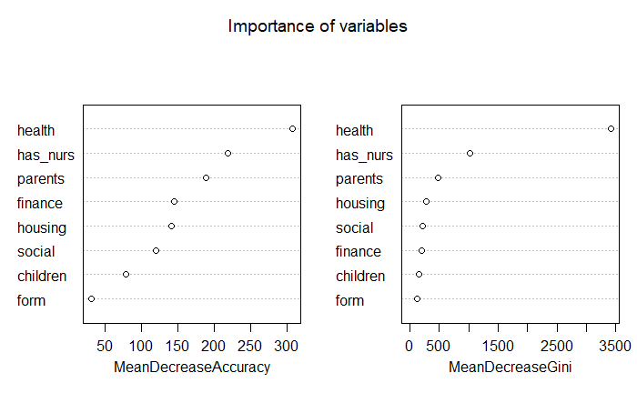

```r
varImpPlot(fitRF1,main = "Importance of variables")
```

### Prediction with Randow Forest Iteration 1

```r
PredictionRF1 <- predict(fitRF1, test.data)
head(PredictionRF1)
```

```
         2          9         11         13         28         37
 recommend  not_recom   priority very_recom very_recom   priority
Levels: not_recom recommend very_recom priority spec_prior
```

### Evaluation of prediction

```r
 confusionMatrix(data=PredictionRF1,test.data$class)
```

```
Confusion Matrix and Statistics

            Reference
Prediction   not_recom recommend very_recom priority spec_prior
  not_recom        864         0          0        0          0
  recommend          0       150          0        1          0
  very_recom         0         0          6        0          0
  priority           0         6         18      691          3
  spec_prior         0        18          0       31        803

Overall Statistics

               Accuracy : 0.9703
                 95% CI : (0.963, 0.9765)
    No Information Rate : 0.3335
    P-Value [Acc > NIR] : < 2.2e-16

                  Kappa : 0.9579
 Mcnemar's Test P-Value : NA

Statistics by Class:

                     Class: not_recom Class: recommend Class: very_recom Class: priority Class: spec_prior
Sensitivity                    1.0000          0.86207          0.250000          0.9557            0.9963
Specificity                    1.0000          0.99959          1.000000          0.9855            0.9725
Pos Pred Value                 1.0000          0.99338          1.000000          0.9624            0.9425
Neg Pred Value                 1.0000          0.99016          0.993037          0.9829            0.9983
Prevalence                     0.3335          0.06716          0.009263          0.2790            0.3111
Detection Rate                 0.3335          0.05789          0.002316          0.2667            0.3099
Detection Prevalence           0.3335          0.05828          0.002316          0.2771            0.3288
Balanced Accuracy              1.0000          0.93083          0.625000          0.9706            0.9844
```

### Simple way to calculate accuracy

```r
confMat <- table(PredictionRF1,test.data$class)
confMat
```

```
PredictionRF1 not_recom recommend very_recom priority spec_prior
   not_recom        864         0          0        0          0
   recommend          0       150          0        1          0
   very_recom         0         0          6        0          0
   priority           0         6         18      691          3
   spec_prior         0        18          0       31        803
```

```r
accuracy <- sum(diag(confMat))/sum(confMat)
cat(sprintf("\nAccuracy=%f", accuracy))
```

```
Accuracy=0.970282
```

### Evaluate again - tr

```r
train_control <- trainControl(method="cv", number=10)
set.seed(7)
rpart.grid <- expand.grid(mtry = 5)
kf_DT <- train(as.factor(class)~., train.data, method="rf", trControl=train_control,tuneGrid=rpart.grid)
print(kf_DT)
```

```
Random Forest

10369 samples
    8 predictor
    5 classes: 'not_recom', 'recommend', 'very_recom', 'priority', 'spec_prior'

No pre-processing
Resampling: Cross-Validated (10 fold)
Summary of sample sizes: 9332, 9333, 9332, 9332, 9332, 9332, ...
Resampling results:

  Accuracy   Kappa
  0.9709711  0.9590022

Tuning parameter 'mtry' was held constant at a value of 5
```

```r
t_pred <- predict(kf_DT, test.data, type="raw")
confMat <- table(PredictionRF1,test.data$class)
confMat
```

```
PredictionRF1 not_recom recommend very_recom priority spec_prior
   not_recom        864         0          0        0          0
   recommend          0       150          0        1          0
   very_recom         0         0          6        0          0
   priority           0         6         18      691          3
   spec_prior         0        18          0       31        803
```

```r
accuracy <- sum(diag(confMat))/sum(confMat)
cat(sprintf("\nAccuracy=%f", accuracy))
```

```
Accuracy=0.970282
```